# 02 - Male morph discrimination

02_morph_discrimination.qmd

# Overview

This document outlines the investigation into the potential existence of male trimorphism in *Longiperna concolor* and details the procedures used for male morph discrimination.

# Load data

The `MALES` dataset, generated using the `01_exploratory_analysis.qmd` file, contains individual-level information–such as ID, sex, and body measurements–for all *L. concolor* males analyzed in this study. It also includes the morph classifications established by Zatz et al. (2011).

```
'data.frame':   631 obs. of  4 variables:
 $ ID       : Factor w/ 631 levels "100M","101M",..: 109 218 321 417 494 555 588 620 631 11 ...
 $ DSmm     : num  6.1 5.44 6.03 6.02 5.61 5.71 5.59 6 5.76 5.98 ...
 $ F4mm     : num  57 31.5 55.3 57.5 35.7 ...
 $ MorphZatz: Factor w/ 2 levels "Major","Minor": 1 1 1 1 1 1 1 1 1 1 ...
```

# Classifying male morphs with mixture models

## Univariate models

Here, we adopt the common procedure of establishing polymorphism through univariate mixture models, fitted solely to fourth femur length (i.e., the threat device) using the `mixsmsn` package (Prates, Cabral, and Lachos 2013). We then compare models comprising mixtures of one, two and three skewed normal distributions.

*Note: As stated by Prates, Cabral, and Lachos (2013) in the package description, the* `nu` *parameter is ignored in finite mixture skewed normal models and, therefore, its value is irrelevant.*

```r
# Univariate unimodal
SN.Mix1 <- smsn.mix(y = na.omit(MALES$F4mm), # response vector
                    g = 1, # number of cluster to be considered in fitting
                    nu = 5, # parameter of the scale variable (vector or scalar) of the SMSN family (kurtosis parameter)
                    family = "Skew.normal") # distribution family to be used in fitting

# Univariate bimodal
SN.Mix2 <- smsn.mix(y = na.omit(MALES$F4mm),
                    g = 2,
                    nu = 5,
                    obs.prob = TRUE, # reports the posterior probability of each observation belonging to one of the g groups
                    family = "Skew.normal")

# Univariate trimodal
SN.Mix3 <- smsn.mix(y = na.omit(MALES$F4mm),
                    g = 3,
                    nu = 5,
                    obs.prob = TRUE,
                    family = "Skew.normal")
```

As we can see, according to the Akaike Information Criterion (AIC), male fourth femur length is best described as trimodal, but with a 𝛥AIC slightly above 2.

```
      uni      bi     tri unibi unitri bitri     type
1 4786.28 4708.07 4705.56  78.2  80.71  2.51 trimodal
```

Below, we show both the bimodal and trimodal density curves plotted over the fourth femur length histogram:

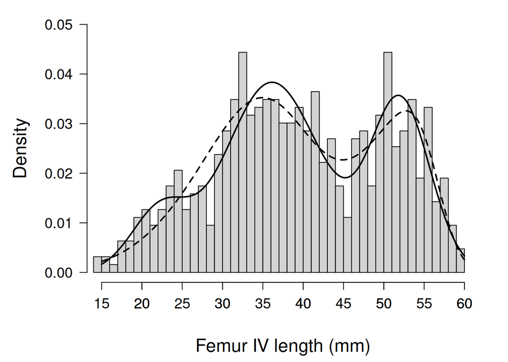

Figure 1: Frequency histogram for femur IV length in the harvestman *Longiperna concolor*. The solid line represents the best-fitting univariate distribution, with three male morphs, while the dashed line represents the univariate distribution with two male morphs.

## Bivariate models

To further assess the trimodality suggested above, we explored providing additional information to the mixture model by also including dorsal scute length. Since dorsal scute length is unimodal, if it were equally distributed across morphs we would expect results similar to those from the univarite model. Conversely, if males were clustered into groups defined jointly by body and leg size, we would expect the trimodal model to have the lowest AIC, with a larger 𝛥AIC separating it from the competing models.

```r
multimod1 <- smsn.mmix(cbind(MALES$F4mm,MALES$DSmm),
                       nu = 5,
                       g = 1,
                       get.init = TRUE,
                       family = "Skew.normal",
                       group = TRUE)
multimod2 <- smsn.mmix(cbind(MALES$F4mm,MALES$DSmm),
                       nu = 5,
                       g = 2,
                       get.init = TRUE,
                       family = "Skew.normal",
                       obs.prob = TRUE,
                       group = TRUE)
multimod3 <- smsn.mmix(cbind(MALES$F4mm,MALES$DSmm),
                       nu = 5,
                       g = 3,
                       get.init = TRUE,
                       family = "Skew.normal",
                       obs.prob = TRUE,
                       group = TRUE)
```

When incorporating dorsal scute length, AIC values consistently support trimodality, with larger 𝛥AIC values compared to the univariate analysis. This indicates that the trimodal distribution is not only more adequate, but also that dorsal scute length contributes substantially to the clustering structure and should therefore be considered in further analyses. We therefore adopted the trimodal bivariate model for male morph discrimination.

```
      uni      bi     tri unibi unitri bitri     type
1 4440.34 4354.14 4299.93  86.2 140.41  54.2 trimodal
```

## Final morph discrimination

Given the substantial overlap between morphs and in order to balance classification certainty with retaining as many individuals as possible, we adopted a 80% membership threshold. Because this threshold is somewhat arbitrary, we performed a simple sensitivity analysis to assess how varying the threshold affects the number of individuals classified and subsequent allometry analyses.

As expected, raising the membership probability threshold increases the number of non-identified individuals (NI).

```
  Confidence Alpha Beta Gamma  NI
1       0.80   172  307    59  93
2       0.85   159  295    52 125
3       0.90   141  277    43 170
4       0.95   102  243    31 255
```

However, relative morph frequencies remains mostly stable.

```
  Confidence Alpha Beta Gamma   NI
1       0.80  0.27 0.49  0.09 0.15
2       0.85  0.25 0.47  0.08 0.20
3       0.90  0.22 0.44  0.07 0.27
4       0.95  0.16 0.39  0.05 0.40
```

`MALES` is now a dataset that also includes male morphs classified using the bivariate trimodal mixture model, with membership thresholds of 80%, 85%, 90%, and 95%.

```
'data.frame':   631 obs. of  8 variables:
 $ ID       : Factor w/ 631 levels "100M","101M",..: 109 218 321 417 494 555 588 620 631 11 ...
 $ DSmm     : num  6.1 5.44 6.03 6.02 5.61 5.71 5.59 6 5.76 5.98 ...
 $ F4mm     : num  57 31.5 55.3 57.5 35.7 ...
 $ MorphZatz: Factor w/ 2 levels "Major","Minor": 1 1 1 1 1 1 1 1 1 1 ...
 $ T80      : Factor w/ 4 levels "NI","Alpha","Beta",..: 2 3 2 2 3 1 2 2 2 2 ...
 $ T85      : Factor w/ 4 levels "NI","Alpha","Beta",..: 2 3 2 2 3 1 2 2 2 2 ...
 $ T90      : Factor w/ 4 levels "NI","Alpha","Beta",..: 2 3 2 2 3 1 2 2 2 2 ...
 $ T95      : Factor w/ 4 levels "NI","Alpha","Beta",..: 2 1 2 2 3 1 2 2 2 2 ...
```

`MORPHPROB`is a dataframe containing the membership probabilities estimated by the same trimodal bivariate model, with individuals listed in the same order as in `MALES`.

```
'data.frame':   631 obs. of  3 variables:
 $ Alpha: num  9.74e-01 4.15e-08 9.70e-01 9.80e-01 4.49e-05 ...
 $ Beta : num  0.0262 0.9344 0.0302 0.0199 0.9938 ...
 $ Gamma: num  0 0.06559 0 0 0.00613 ...
```

Number of large and small non-identified individuals.

```
   Type  N F4mm (mean ± sd)
1 Large 51     46.87 ± 1.03
2 Small 42     26.31 ± 2.01
```

# Reassessment of morph classification

In the plots below, we show the distribution of morphs identified in our study based on their morphological traits (Fig. 2a), as well as the correspondence between the classifications proposed by Zatz et al. (2011) and those obtained here (Fig. 2b). Compared with the original morph classification by Zatz et al. (2011), most majors are now reassigned to either alphas or betas, while nearly all minors fall into the gamma or non-identified categories.

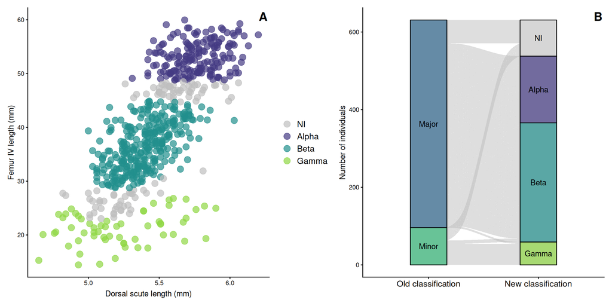

Figure 2: (A) Relationship between femur IV length and dorsal scute length in males, with colors indicating morphs defined by the 80% threshold. (B) Alluvial diagram illustrating the correspondence between morph classifications proposed by Zatz et al. (2011) and those obtained under the 80% threshold criterion.

In terms of absolute and relative numbers, the cross-classification between the morph categories of Zatz et al. (2011) and those obtained under the 80% threshold is shown below:

```
         NI Alpha Beta Gamma
  Major  60   172  298     5
  Minor  33     0    9    54
```

```
          NI Alpha Beta Gamma
  Major 0.11  0.32 0.56  0.01
  Minor 0.34  0.00 0.09  0.56
```

## References

Prates, Marcos, Celso Cabral, and Victor Lachos. 2013. “Mixsmsn: Fitting Finite Mixture of Scale Mixture of Skew-Normal Distributions.” *Journal of Statistical Software* 54 (September): 1–20. https://doi.org/10.18637/jss.v054.i12.

Zatz, Camila, Rachel Werneck, Rogelio Macías-Ordóñez, and G. Machado. 2011. “Alternative Mating Tactics in Dimorphic Males of the Harvestman Longiperna Concolor (Arachnida: Opiliones).” *Behavioral Ecology and Sociobiology* 65 (May): 995–1005. https://doi.org/10.1007/s00265-010-1103-0.